# Seurat_PBMC_Draft

### Scatterplot

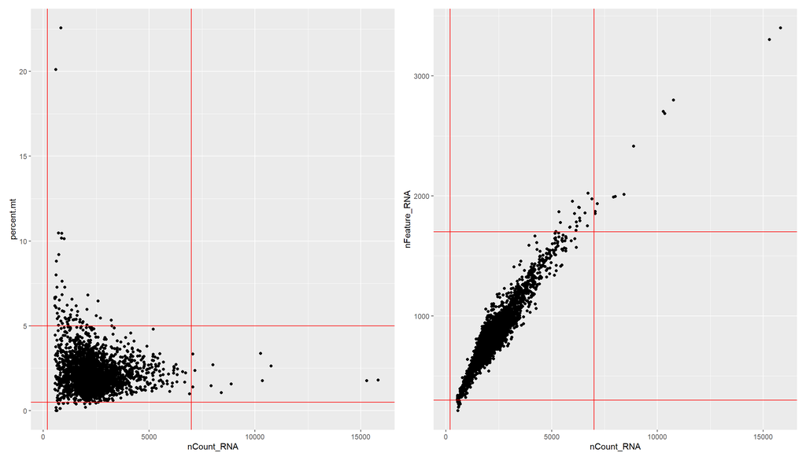

```r
CountMT <- ggplot(pbmc@meta.data, aes(nCount_RNA, percent.mt)) +
  geom_point() +
  geom_hline(yintercept = c(0.5, 5), color = c("red", "red")) +
  geom_vline(xintercept = c(200, 7000), color = c("red", "red"))

CountFeature <- ggplot(pbmc@meta.data, aes(nCount_RNA, nFeature_RNA)) +
  geom_point() +
  geom_hline(yintercept = c(300, 1700), color = c("red", "red")) +
  geom_vline(xintercept = c(200, 7000), color = c("red", "red"))

CountMT + CountFeature + plot_layout(ncol = 2)
```

## Apply QC

Keep cells with:

- 300 - 1700 unique genes
- 200 - 7000 total RNA molecules
- 0.5 - 5% mitochondrial gene percentage

```r
pbmc <- subset(pbmc, subset = nFeature_RNA > 300 & nFeature_RNA < 1700 &
                 nCount_RNA > 200 & nCount_RNA < 7000 &
                 percent.mt > 0.5 & percent.mt < 5)
```

### View post QC

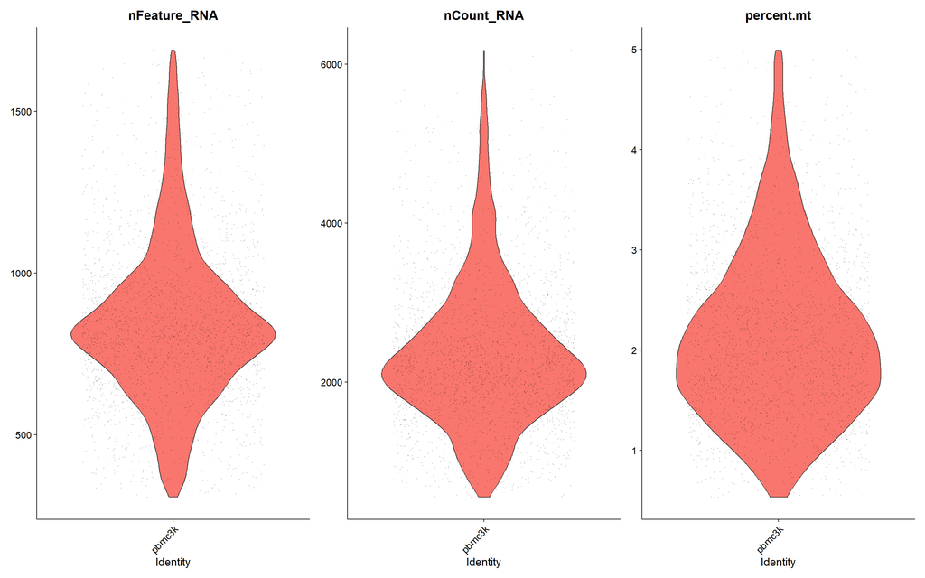

```r
# Violin plots
VlnPlot(pbmc, features = c("nFeature_RNA", "nCount_RNA", "percent.mt"), ncol = 3, alpha = 0.2)
```

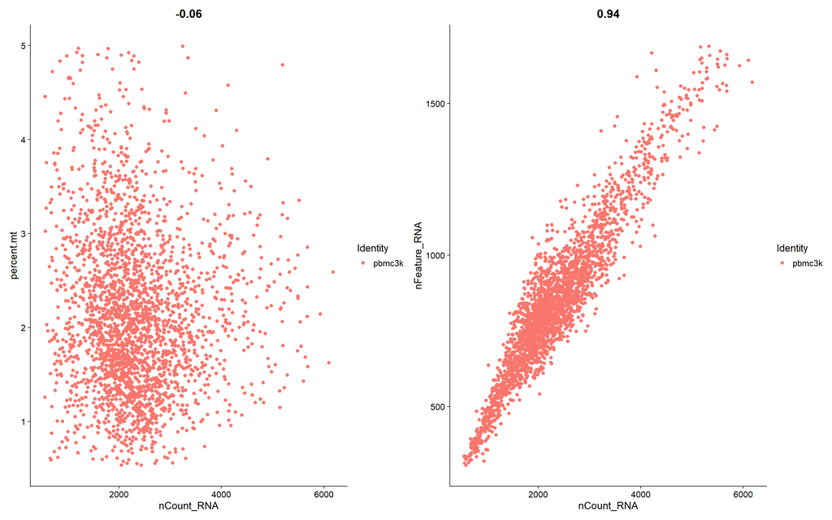

```r
# Scatter plots
FeatureScatter(pbmc, feature1 = "nCount_RNA", feature2 = "percent.mt",  pt.size = 2) + FeatureScatter(pbmc, feature1 = "nCount_RNA", feature2 = "nFeature_RNA", pt.size = 2) + plot_layout(ncol = 2)
```

# Normalize & Transform data

## Normalize

Normalizes feature expression by total expression with “LogNormalize” method, multiply by a scaling factor (10,000 by default)

Normalized values are stored in pbmc[[“RNA”]]$data.

```r
pbmc <- NormalizeData(pbmc, normalization.method = "LogNormalize", scale.factor = 10000)
```

```
## Normalizing layer: counts
```

# Feature Selection

## Stabalize variance

```r
# Return 2,000 features per dataset
pbmc <- FindVariableFeatures(pbmc, selection.method = "vst", nfeatures = 2000)
```

```
## Finding variable features for layer counts
```

## Plot mean by variance

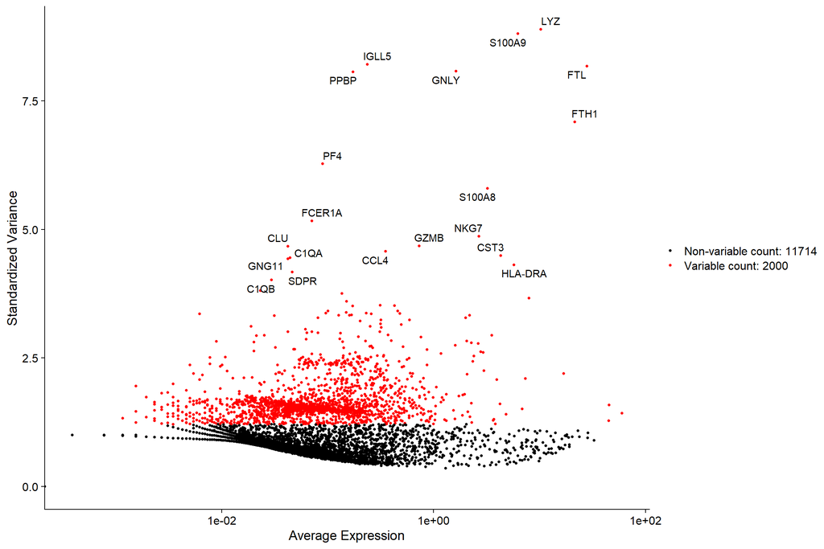

```r
# top 20 most variable genes
top20 <- head(VariableFeatures(pbmc), 20)

# plot with labels
plot1 <- VariableFeaturePlot(pbmc)

LabelPoints(plot1, top20,
            repel = TRUE,
            xnudge = 0,
            ynudge = 0)
```

## Scale data

Before dimensionality reduction methods such as UMAP and PCA plots, use ScaleData() function to prevent domination by highly-expressed genes.  
- Scale expression of each gene, so the variance is 1  
- Shift expression of each gene, so the mean is 0

Results are stored in pbmc[[“RNA”]]$scale.data

```r
all.genes <- rownames(pbmc)

pbmc <- ScaleData(pbmc, features = all.genes)
```

# Dimensionailty reduction

## Principle Components

```r
# Extract principle components & save into Seurat object
pbmc <- RunPCA(pbmc, features = VariableFeatures(object = pbmc))

# Save TSNE
pbmc <- RunTSNE(pbmc, features = VariableFeatures(object = pbmc))

# Save UMAP
pbmc <- RunUMAP(pbmc, features = VariableFeatures(object = pbmc))
```

### Explore PC’s

VizDimReduction(), DimPlot(), and DimHeatmap()

```r
# print top 3 PC's most significant genes
print(pbmc[["pca"]], dims = 1:3, nfeatures = 5)
```

```
## PC_ 1
## Positive:  MALAT1, LTB, IL32, IL7R, CD2
## Negative:  CST3, TYROBP, LST1, AIF1, FTL
## PC_ 2
## Positive:  NKG7, PRF1, GZMB, CST7, GZMA
## Negative:  CD79A, MS4A1, TCL1A, HLA-DQA1, HLA-DQB1
## PC_ 3
## Positive:  IL7R, VIM, IL32, TMSB4X, S100A6
## Negative:  CD79A, CD79B, HLA-DQA1, MS4A1, HLA-DQB1
```

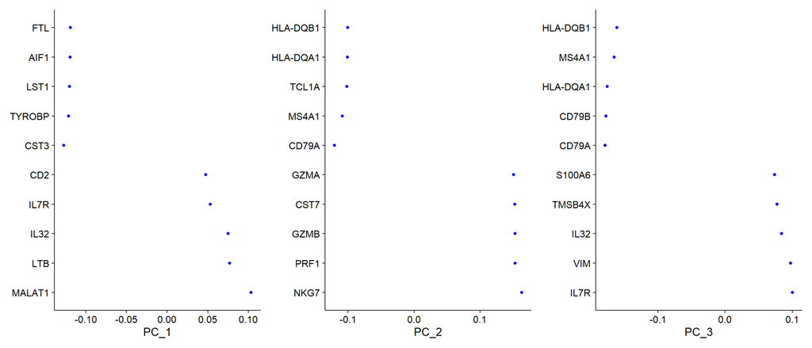

```r
# Plot top 3 PC's most significant genes
VizDimLoadings(pbmc, dims = 1:3, nfeatures = 10, reduction = "pca", balanced = TRUE, ncol = 3)
```

## Dim Down Plots

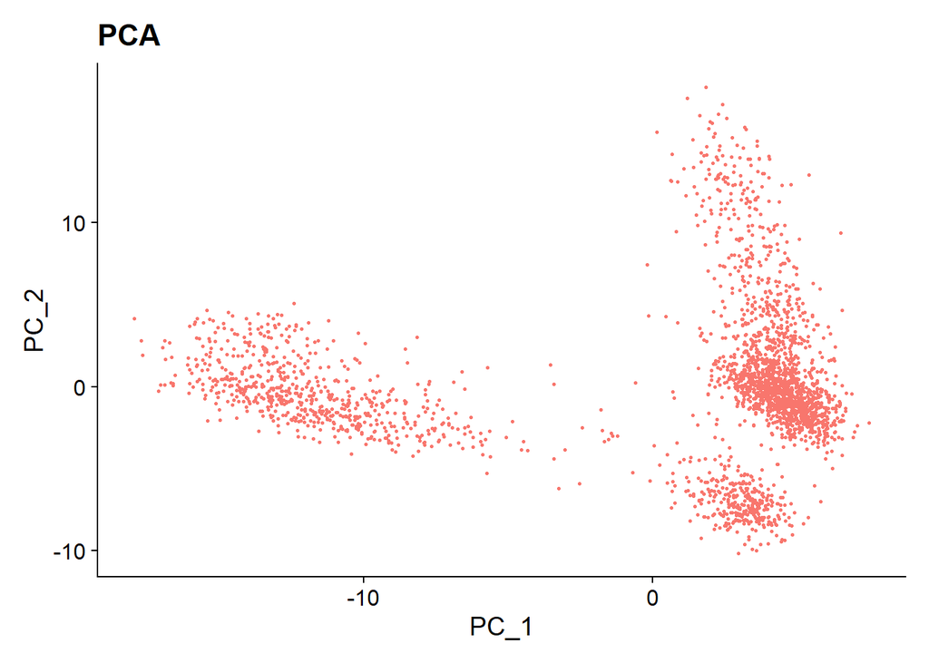

```r
# Dimplot() will function for all these pots
# PCA plot
PCAPlot(pbmc, reduction = "pca") + NoLegend() + labs(title="PCA")
```

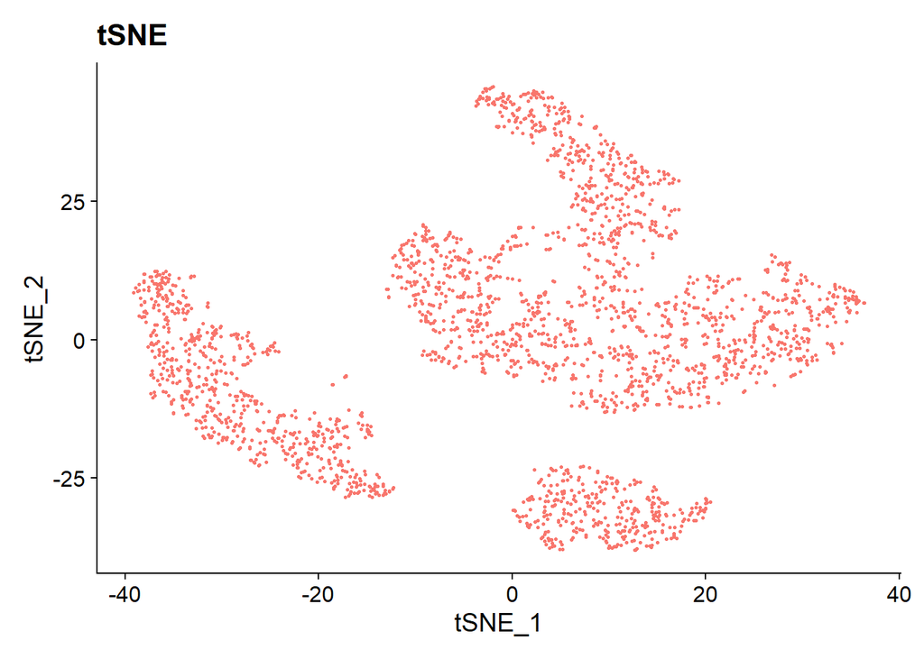

```r
# TSNE plot
TSNEPlot(pbmc, reduction = "tsne") + NoLegend() + labs(title="tSNE")
```

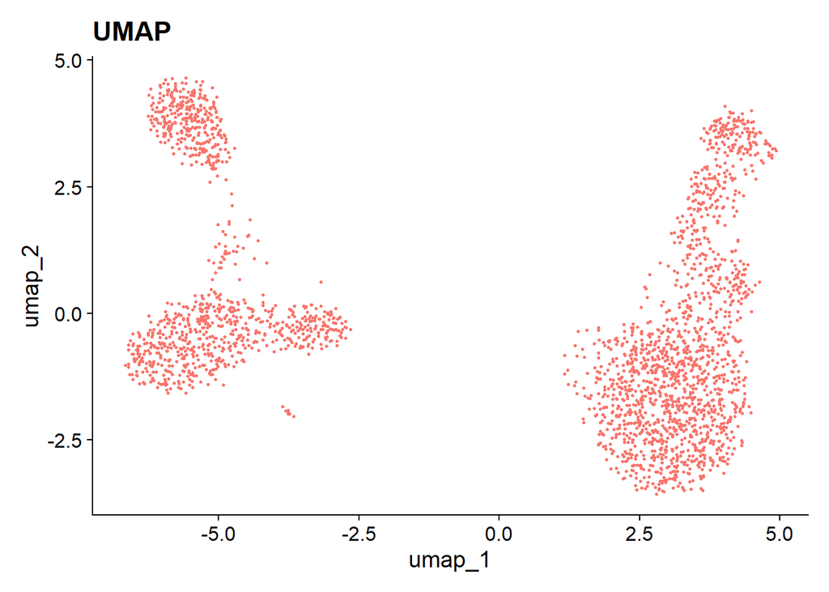

```r
# UMAP
UMAPPlot(pbmc, reduction = "umap") + NoLegend() + labs(title="UMAP")
```

## Heatmaps

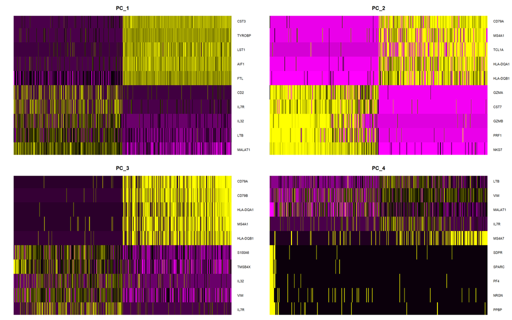

```r
DimHeatmap(pbmc, dims = c(1:4),
           nfeatures = 10, cells = 500, ncol = 2,
           balanced = TRUE, reduction = "pca")
```

# Determine Clusters

## Elbowplot

This plot shows the variation (y) that can be described by a given number of PC’s (x). As the variation stabalizes, we can determine the number of principle components that acuratly describe most of the variation within a dataset. In this case i would choose 8-10 depending on my intentions for the analysis.

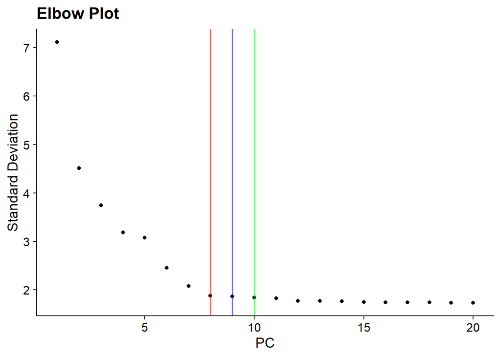

```r
ElbowPlot(pbmc) +
  geom_vline(xintercept = c(8, 9, 10), color = c("red", "blue", "green")) +
  labs(title = "Elbow Plot")
```

## Distance metric

Using the FindNeighbors() function:  
- construct a KNN graph based on euclidean distances in PCA space  
- refine the edge weights between any two cells based on the shared overlap in their local neighborhoods (Jaccard similarity)

```r
pbmc <- FindNeighbors(pbmc, dims = 1:9)
```

## Cluster Cells

Using FindClusters() function:  
- Calculate k-nearest neighbors and construct the SNN graph.  
- Optimize the modularity function to determine clusters

A resolution parameter between 0.4-1.2 is ideal for ~3K single-cell data.  
Optimal resolution increases with dataset.

```r
pbmc <- FindClusters(pbmc, resolution = 0.5)
```

```
## Modularity Optimizer version 1.3.0 by Ludo Waltman and Nees Jan van Eck
##
## Number of nodes: 2588
## Number of edges: 91404
##
## Running Louvain algorithm...
## Maximum modularity in 10 random starts: 0.8745
## Number of communities: 8
## Elapsed time: 0 seconds
```

```r
# View cluster assignments
head(Idents(pbmc), 5)
```

```
## AAACATACAACCAC-1 AAACATTGAGCTAC-1 AAACATTGATCAGC-1 AAACCGTGCTTCCG-1
##                1                3                1                5
## AAACCGTGTATGCG-1
##                6
## Levels: 0 1 2 3 4 5 6 7
```

## Clustered Dimed Down

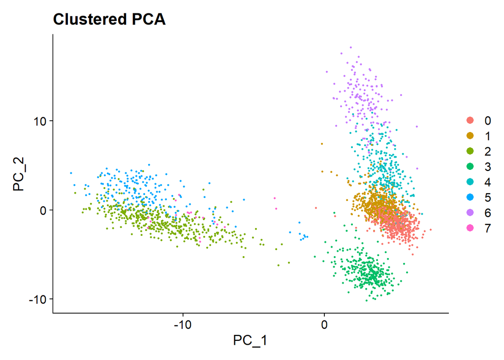

```r
# Extract principle components & save into Seurat object
pbmc <- RunPCA(pbmc, dims = 1:9)

# PCA plot
PCAPlot(pbmc, reduction = "pca") + labs(title="Clustered PCA")
```

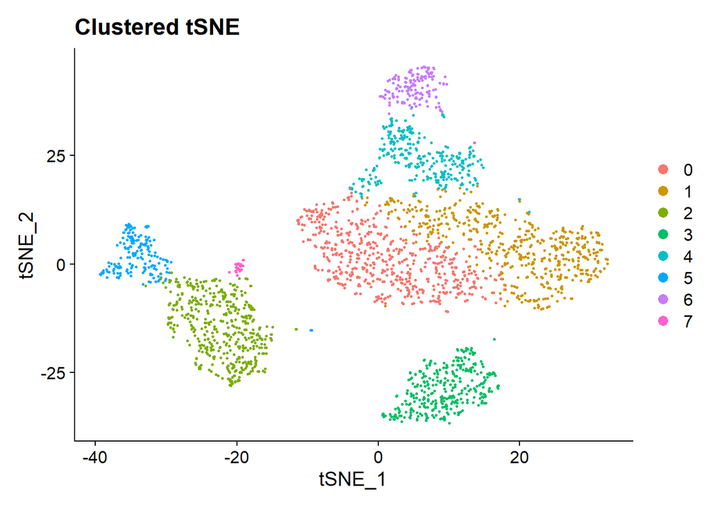

```r
# Save TSNE
pbmc <- RunTSNE(pbmc, dims = 1:9)

# TSNE plot
TSNEPlot(pbmc, reduction = "tsne") + labs(title="Clustered tSNE")
```

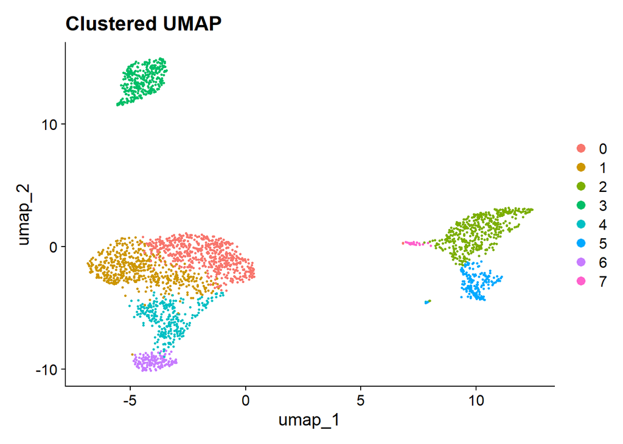

```r
# Run UMAP calculations with newly clustered cells
pbmc <- RunUMAP(pbmc, dims = 1:9)

# Plot UMAP
UMAPPlot(pbmc, reduction = "umap") + labs(title="Clustered UMAP")
```

# Differential Gene Expression

## Identify cluster features

```r
# find all markers of cluster 2
cluster2.markers <- FindMarkers(pbmc, ident.1 = 2)

head(cluster2.markers, n = 5)
```

```
##                p_val avg_log2FC pct.1 pct.2     p_val_adj
## S100A8  0.000000e+00   6.421435 0.978 0.129  0.000000e+00
## LGALS2  0.000000e+00   5.482369 0.908 0.066  0.000000e+00
## S100A9  0.000000e+00   5.970127 0.996 0.222  0.000000e+00
## FCN1   5.017886e-305   3.951801 0.954 0.156 6.881529e-301
## CD14   4.745812e-301   5.920096 0.695 0.030 6.508406e-297
```

```r
# find all markers distinguishing cluster 5 from clusters 0 and 3
cluster5.markers <- FindMarkers(pbmc, ident.1 = 5, ident.2 = c(0, 3))

head(cluster5.markers, n = 5)
```

```
##                p_val avg_log2FC pct.1 pct.2     p_val_adj
## IFITM3 2.911025e-183   6.134180 0.941 0.048 3.992180e-179
## FCGR3A 4.842991e-182   6.760032 0.904 0.036 6.641677e-178
## CFD    1.154870e-178   5.983351 0.904 0.040 1.583789e-174
## CD68   1.561259e-172   5.362181 0.882 0.038 2.141110e-168
## FCER1G 5.473783e-171   6.460346 0.963 0.089 7.506746e-167
```

```r
# find markers all cluster compared to all remaining cells, report only the positive ones
pbmc.markers <- FindAllMarkers(pbmc, only.pos = TRUE)
pbmc.markers |>
  group_by(cluster) |>
  filter(avg_log2FC > 1)
```

```
## # A tibble: 6,208 × 7
## # Groups:   cluster [8]
##        p_val avg_log2FC pct.1 pct.2 p_val_adj cluster gene
##        <dbl>      <dbl> <dbl> <dbl>     <dbl> <fct>   <chr>
##  1 1.55e-110       1.22 0.936 0.596 2.12e-106 0       LDHB
##  2 4.00e-101       2.54 0.494 0.109 5.49e- 97 0       CCR7
##  3 8.59e- 66       1.03 0.857 0.421 1.18e- 61 0       CD3D
##  4 3.38e- 55       2.16 0.368 0.105 4.63e- 51 0       LEF1
##  5 9.01e- 51       1.26 0.662 0.361 1.24e- 46 0       NOSIP
##  6 7.58e- 49       1.58 0.477 0.185 1.04e- 44 0       PIK3IP1
##  7 3.51e- 46       2.00 0.355 0.114 4.81e- 42 0       PRKCQ-AS1
##  8 2.75e- 45       2.79 0.218 0.041 3.77e- 41 0       FHIT
##  9 5.52e- 43       1.02 0.618 0.297 7.56e- 39 0       CD7
## 10 1.69e- 39       2.92 0.175 0.028 2.31e- 35 0       LINC00176
## # ℹ 6,198 more rows
```

```r
# ROC test returns ‘classification power’ individual markers (0=random, to 1=perfect).
cluster0.markers <- FindMarkers(pbmc, ident.1 = 0, logfc.threshold = 0.25,
                                test.use = "roc", only.pos = TRUE)

head(cluster0.markers)
```

```
##       myAUC  avg_diff power avg_log2FC pct.1 pct.2
## RPS6  0.830 0.4672260 0.660  0.6802275 1.000 0.997
## RPS12 0.830 0.4969190 0.660  0.7254151 1.000 0.994
## RPL32 0.826 0.4316360 0.652  0.6296283 0.998 0.997
## RPS27 0.824 0.4945441 0.648  0.7222220 0.998 0.993
## RPS14 0.813 0.4218663 0.626  0.6167222 1.000 0.996
## RPL31 0.810 0.5376612 0.620  0.7973715 1.000 0.965
```

## View results

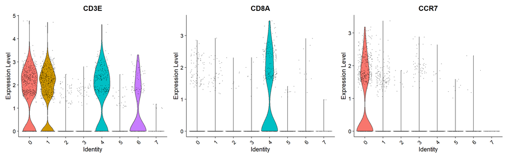

```r
# Violin Plot
VlnPlot(pbmc, features = c("CD3E", "CD8A", "CCR7"))
```

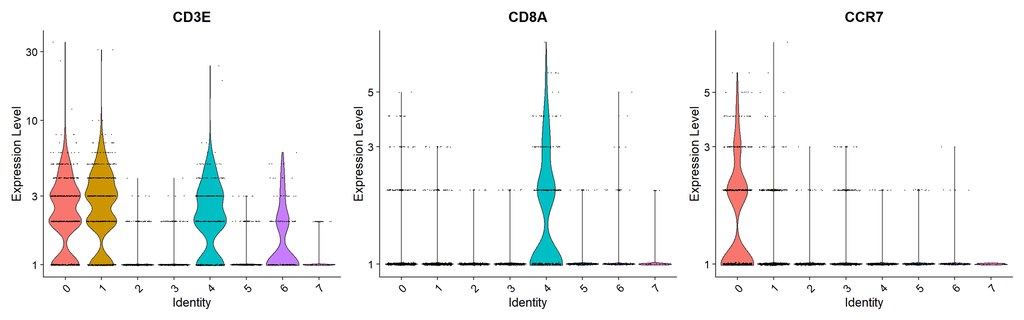

```r
# Plot raw counts as well
VlnPlot(pbmc, features = c("CD3E", "CD8A", "CCR7"), slot = "counts", log = TRUE)
```

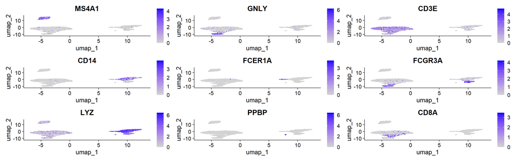

```r
# Single marker UMAPS
FeaturePlot(pbmc, features = c("MS4A1", "GNLY", "CD3E", "CD14", "FCER1A", "FCGR3A", "LYZ", "PPBP",
    "CD8A"))
```

## Heatmap

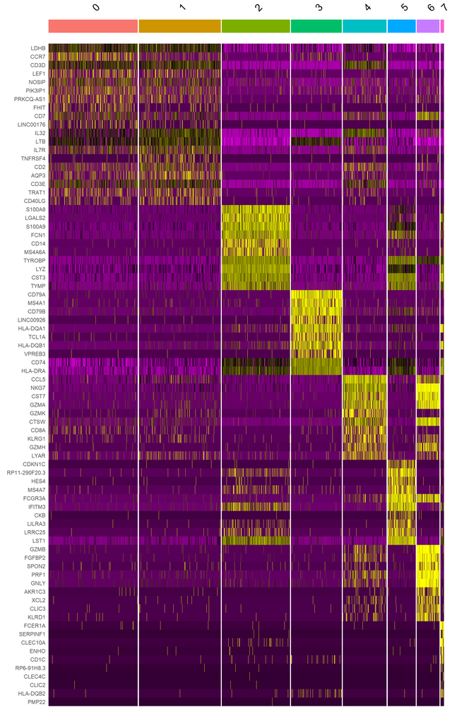

```r
top10 <- pbmc.markers |>
  group_by(cluster) |>
  filter(avg_log2FC > 1) |>
  slice_head(n = 10) |>
  ungroup()

DoHeatmap(pbmc, features = top10$gene) + NoLegend()
```

## Widefield View

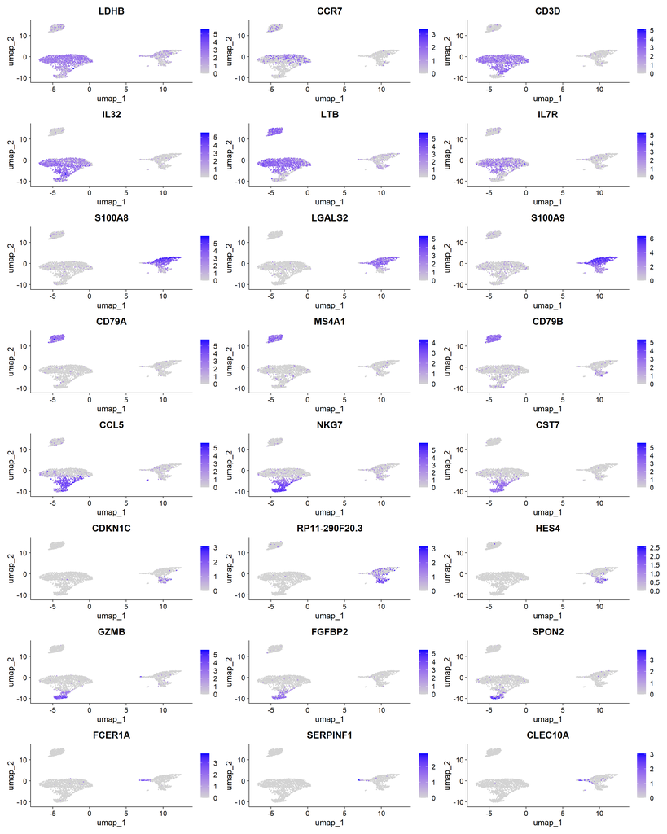

```r
# Extract top 3 cluster identifying markers
ClusID <- top10 |>
  select(cluster, gene) |>
  group_by(cluster) |>
  slice_head(n=3) |>
  ungroup()

# UMAP visualization
FeaturePlot(pbmc, features = ClusID$gene, ncol = 3)
```

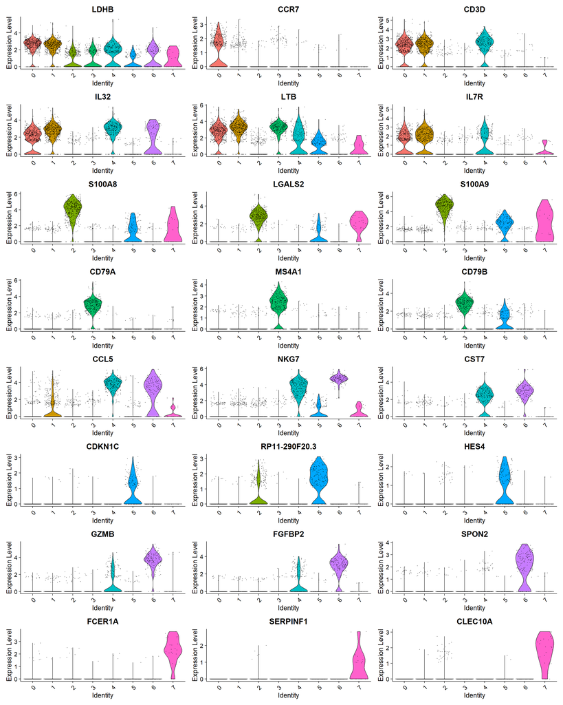

```r
# Violin plots
VlnPlot(pbmc, features = ClusID$gene, ncol = 3)
```

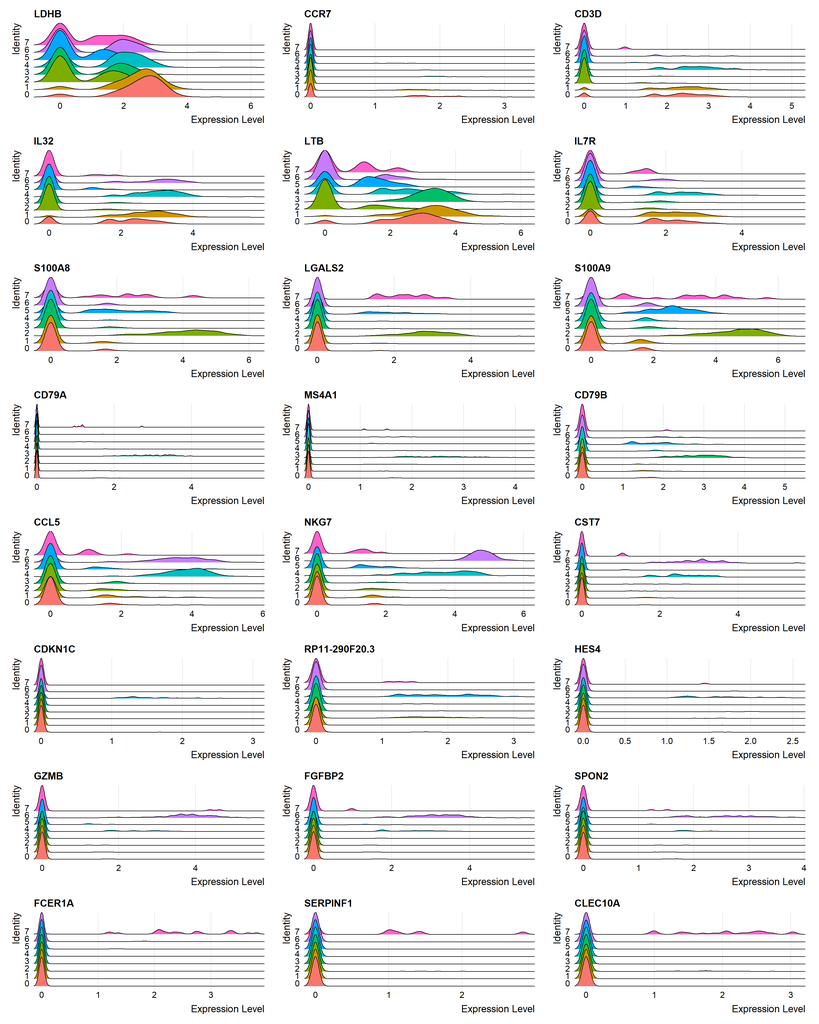

```r
# Ridgeplots
RidgePlot(pbmc, features = ClusID$gene, ncol = 3)
```

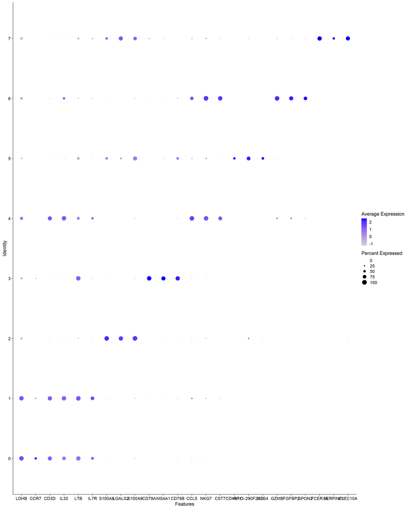

```r
# Dotplot
DotPlot(pbmc, features =  ClusID$gene)
```

## Interactive exploration

```r
# # Plot something
# plot <- FeaturePlot(pbmc, features = "CD8A")
#
# # Run interactive plot
# HoverLocator(plot = plot, information = FetchData(pbmc, vars = c("ident", "PC_1", "nFeature_RNA")))
```

## Label Clusters

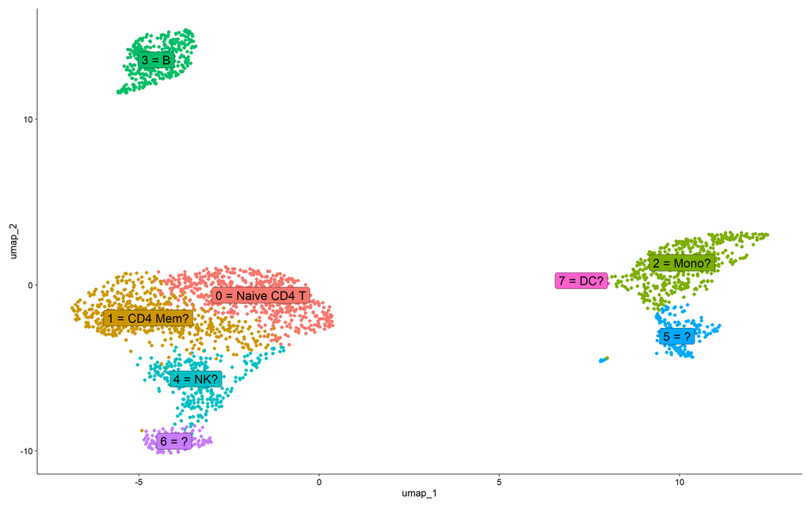

```r
# Save label names as characters
clusterIDs <- c("0 = Naive CD4 T", "1 = CD4 Mem?",
                     "2 = Mono?", "3 = B",
                     "4 = NK?", "5 = ?",
                     "6 = ?", "7 = DC?")

# Assign cluster levels to names of ClusterID DF
names(clusterIDs) <- levels(pbmc)

# Rename Clusters
pbmc <- RenameIdents(pbmc, clusterIDs)

# Plot UMAP with labels
DimPlot(pbmc, reduction = "umap", label = TRUE, pt.size = 2,
        label.size = 6, label.box = TRUE) + NoLegend()
```

# Save Seurat Object

```r
# saveRDS(pbmc, file = paste(getwd(), "output/pbmc.rds", sep = "/"))
```